# Known map experiment - total number of network packets

We are analyzing if offloading any of the three functionalities (i.e., localisation, navigation and object recognition) has a statistically significant effect on the total number of network packets. Fist, install and load the required libraries:

```r
if (!require('tidyverse')) install.packages('tidyverse', dependencies = TRUE); library('tidyverse')
if (!require('ggpubr')) install.packages('ggpubr', dependencies = TRUE); library('ggpubr')
if (!require('rstatix')) install.packages('rstatix', dependencies = TRUE); library('rstatix')
if (!require('ggplot2')) install.packages('ggplot2', dependencies = TRUE); library('ggplot2')
if (!require('lmPerm')) install.packages('lmPerm', dependencies = TRUE); library('lmPerm')
```

Next, load the experiment results from the csv file:

```r
data <- read.csv(file = '../../raw_data/known_map_experiment/run_table.csv')
data <- subset(data, select = c(X__run_id, amcl_offloaded, navigation_offloaded, obj_recognition_offloaded, num_of_packets))
data$amcl_offloaded <- as.factor(data$amcl_offloaded)
data$navigation_offloaded <- as.factor(data$navigation_offloaded)
data$obj_recognition_offloaded <- as.factor(data$obj_recognition_offloaded)
data$num_of_packets <- as.numeric(data$num_of_packets)
```

Mean and standard deviation of the total number of network packets for each treatment are displayed in the summary below:

```r
data %>%
  group_by(amcl_offloaded, navigation_offloaded, obj_recognition_offloaded) %>%
  get_summary_stats(num_of_packets, type = "mean_sd")
```

| amcl_offloaded | navigation_offloaded | obj_recognition_offloaded | variable | n | mean | sd |
| --- | --- | --- | --- | --- | --- | --- |
| false | false | false | num_of_packets | 10 | 2154.7 | 65.669 |
| false | false | true | num_of_packets | 10 | 45014.8 | 3400.478 |
| false | true | false | num_of_packets | 10 | 28184.6 | 1754.292 |
| false | true | true | num_of_packets | 10 | 63842.0 | 8805.123 |
| true | false | false | num_of_packets | 10 | 16944.9 | 494.590 |
| true | false | true | num_of_packets | 10 | 62507.3 | 11027.191 |
| true | true | false | num_of_packets | 10 | 39878.6 | 1408.009 |
| true | true | true | num_of_packets | 10 | 61753.7 | 5256.334 |

# Three-Way ANOVA test

Since there are three independent variables in the experiment, we opt for three-way ANOVA test. First, we need to check if all assumptions for performing the test are met. The fist assumption of having independent observations is met inherently according to the way the experiment itself is conducted.

## No extreme outliers assumption

Next, we need to check if there are any extreme outliers:

```r
data %>%
  group_by(amcl_offloaded, navigation_offloaded, obj_recognition_offloaded) %>%
  identify_outliers(num_of_packets)
```

| amcl_offloaded | navigation_offloaded | obj_recognition_offloaded | X__run_id | num_of_packets | is.outlier | is.extreme |
| --- | --- | --- | --- | --- | --- | --- |
| false | false | false | run_7 | 2270 | TRUE | FALSE |
| false | false | false | run_71 | 2273 | TRUE | FALSE |
| false | false | true | run_75 | 51299 | TRUE | FALSE |
| false | true | false | run_54 | 32686 | TRUE | TRUE |
| false | true | true | run_18 | 84132 | TRUE | FALSE |
| true | false | false | run_48 | 16047 | TRUE | FALSE |
| true | false | false | run_55 | 17760 | TRUE | FALSE |
| true | false | true | run_43 | 86691 | TRUE | FALSE |
| true | true | false | run_3 | 42709 | TRUE | TRUE |
| true | true | false | run_12 | 37594 | TRUE | FALSE |

[output cut: 2 more lines]

The results show that there are 12 outliers, while only runs 54 and 3, represent extreme outliers. We should remove the said runs from the dataset, but we can also leave them if we beleive that they will not have a significant effect on the obtained results. Let us make an alternative dataset with the extreme outliers being removed:

```r
data_without_outliers <- data
data_without_outliers <- data_without_outliers[!(data_without_outliers$X__run_id == 'run_54'),]
data_without_outliers <- data_without_outliers[!(data_without_outliers$X__run_id == 'run_3'),]
```

We proceed to check the next assumption - normality of the data.

## Normality assumption by analyzing the model residuals

The first way to check normality assumption is by analyzing the model residuals:

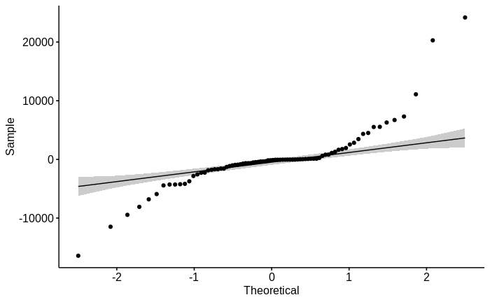

```r
model  <- lm(num_of_packets ~ amcl_offloaded*navigation_offloaded*obj_recognition_offloaded, data = data)
ggqqplot(residuals(model))
```

```r
shapiro_test(residuals(model)) %>%
  add_significance()
```

| variable | statistic | p.value | p.value.signif |
| --- | --- | --- | --- |
| residuals(model) | 0.7925784 | 2.955249e-09 | **** |

The p-value of $2.955 \cdot 10^{-9}$ shows that we can reject $H_0$, which states that the data is indeed normally distributed. We can conclude that the normally constraint is not satisfied. If we try with the dataset that does not contain outliers:

```r
model_without_outliers  <- lm(num_of_packets ~ amcl_offloaded*navigation_offloaded*obj_recognition_offloaded, data = data_without_outliers)
shapiro_test(residuals(model_without_outliers)) %>%
  add_significance()
```

| variable | statistic | p.value | p.value.signif |
| --- | --- | --- | --- |
| residuals(model_without_outliers) | 0.7830565 | 2.26212e-09 | **** |

we get very similar results that lead to the conclusion that normality of residuals is indeed not satisfied.

## Normality assumption by each group

The other way to check normality is by analyzing if samples for each possible treatment combination are normally distributed:

```r
data %>%
  group_by(amcl_offloaded, navigation_offloaded, obj_recognition_offloaded) %>%
  shapiro_test(num_of_packets) %>%
  add_significance()
```

| amcl_offloaded | navigation_offloaded | obj_recognition_offloaded | variable | statistic | p | p.signif |
| --- | --- | --- | --- | --- | --- | --- |
| false | false | false | num_of_packets | 0.7839615 | 0.009251289 | ** |
| false | false | true | num_of_packets | 0.9412992 | 0.567559154 | ns |
| false | true | false | num_of_packets | 0.7629516 | 0.005131823 | ** |
| false | true | true | num_of_packets | 0.8990415 | 0.213843752 | ns |
| true | false | false | num_of_packets | 0.9691125 | 0.882496486 | ns |
| true | false | true | num_of_packets | 0.9429671 | 0.586476231 | ns |
| true | true | false | num_of_packets | 0.9066038 | 0.258467938 | ns |
| true | true | true | num_of_packets | 0.9330468 | 0.478520572 | ns |

Shapiro-Wilk test per each group yields p-value higher than `0.05` for most of the groups, except for the two. If we execute the test on the dataset without extreme outliers:

```r
data_without_outliers %>%
  group_by(amcl_offloaded, navigation_offloaded, obj_recognition_offloaded) %>%
  shapiro_test(num_of_packets) %>%
  add_significance()
```

| amcl_offloaded | navigation_offloaded | obj_recognition_offloaded | variable | statistic | p | p.signif |
| --- | --- | --- | --- | --- | --- | --- |
| false | false | false | num_of_packets | 0.7839615 | 0.009251289 | ** |
| false | false | true | num_of_packets | 0.9412992 | 0.567559154 | ns |
| false | true | false | num_of_packets | 0.9653164 | 0.851976354 | ns |
| false | true | true | num_of_packets | 0.8990415 | 0.213843752 | ns |
| true | false | false | num_of_packets | 0.9691125 | 0.882496486 | ns |
| true | false | true | num_of_packets | 0.9429671 | 0.586476231 | ns |
| true | true | false | num_of_packets | 0.9095511 | 0.312745390 | ns |
| true | true | true | num_of_packets | 0.9330468 | 0.478520572 | ns |

only one group seems to be non-normally distrbuted, with its p-value being lower than 0.05. The QQ-plots per group are depicted below, where most of the data points seem to be aligned with the reference line, with the exception of the groups that were concluded as not normally distributed in the Shapiro-Wilk test:

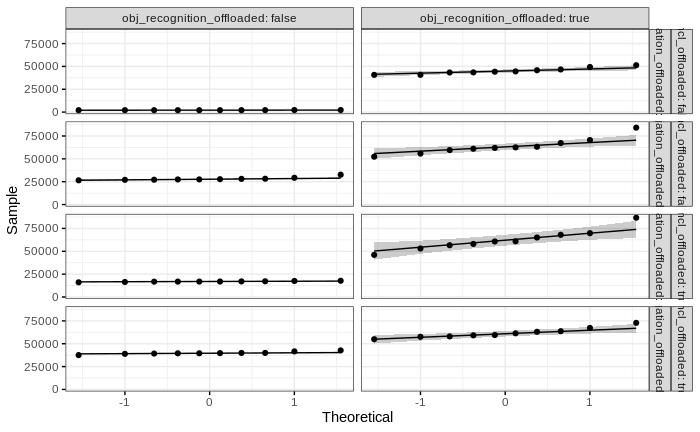

```r
ggqqplot(data, "num_of_packets", ggtheme = theme_bw()) +
  facet_grid(amcl_offloaded + navigation_offloaded ~ obj_recognition_offloaded, labeller = "label_both")
```

## Homogeneity of variance assumption

Homogeneity of variance assumption can be checked via Levene’s test:

```r
data %>%
  levene_test(num_of_packets ~ amcl_offloaded*navigation_offloaded*obj_recognition_offloaded) %>%
  add_significance()
```

| df1 | df2 | statistic | p | p.signif |
| --- | --- | --- | --- | --- |
| 7 | 72 | 4.82725 | 0.0001691945 | *** |

Since the p-value is lower than `0.05`, the result of the Levene’s test is statistically significant, hence the null hypothesis stating that homogeneity of variance holds is rejected. If we compute the Levene’s test on dataset without extreme outliers:

```r
data_without_outliers %>%
  levene_test(num_of_packets ~ amcl_offloaded*navigation_offloaded*obj_recognition_offloaded) %>%
  add_significance()
```

| df1 | df2 | statistic | p | p.signif |
| --- | --- | --- | --- | --- |
| 7 | 70 | 4.955145 | 0.0001367105 | *** |

we can draw the same conclusion - homogeneity of variance assumption is not satisfied. With the disputable normality constraint and no homogeneity of variance, we need to turn to non-parametric alternative of three-way ANOVA - permutation test.

# Permutation test

Execution of permutation test yields the following result:

```r
summary(aovp(num_of_packets ~ amcl_offloaded*navigation_offloaded*obj_recognition_offloaded, data = data, perm="Prob", maxIter=500000, nCycle=100, Ca=0.001))
```

```
[1] "Settings:  unique SS "
Component 1 :
                                                              Df   R Sum Sq  R Mean Sq  Iter Pr(Prob)
amcl_offloaded                                                 1 2.1933e+09 2.1933e+09 5e+05  < 2e-16 ***
navigation_offloaded                                           1 5.6175e+09 5.6175e+09 5e+05  < 2e-16 ***
amcl_offloaded:navigation_offloaded                            1 6.4281e+08 6.4281e+08 5e+05  7.6e-05 ***
obj_recognition_offloaded                                      1 2.6629e+10 2.6629e+10 5e+05  < 2e-16 ***
amcl_offloaded:obj_recognition_offloaded                       1 1.5346e+08 1.5346e+08 5e+05  0.02863 *
navigation_offloaded:obj_recognition_offloaded                 1 1.1927e+09 1.1927e+09 5e+05  < 2e-16 ***
amcl_offloaded:navigation_offloaded:obj_recognition_offloaded  1 3.3968e+08 3.3968e+08 5e+05  0.00154 **
Residuals                                                     72 2.1927e+09 3.0454e+07
---
Signif. codes:  0 ‘***’ 0.001 ‘**’ 0.01 ‘*’ 0.05 ‘.’ 0.1 ‘ ’ 1
```

Test results show that the main effects are significant for all three independent variables, but there are also significant two-way interaction between all variables, and a significant three-way interaction. If we compare these results with three-way ANOVA results, that is considered as *robust* when sample sizes are equal for each group:

```r
data %>%
  anova_test(num_of_packets ~ amcl_offloaded*navigation_offloaded*obj_recognition_offloaded)
```

```
Coefficient covariances computed by hccm()
```

```
ANOVA Table (type II tests)

                                                         Effect DFn DFd       F        p p<.05   ges
1                                                amcl_offloaded   1  72  72.020 1.89e-12     * 0.500
2                                          navigation_offloaded   1  72 184.459 1.51e-21     * 0.719
3                                     obj_recognition_offloaded   1  72 874.393 5.17e-42     * 0.924
4                           amcl_offloaded:navigation_offloaded   1  72  21.108 1.80e-05     * 0.227
5                      amcl_offloaded:obj_recognition_offloaded   1  72   5.039 2.80e-02     * 0.065
6                navigation_offloaded:obj_recognition_offloaded   1  72  39.166 2.50e-08     * 0.352
7 amcl_offloaded:navigation_offloaded:obj_recognition_offloaded   1  72  11.154 1.00e-03     * 0.134
```

we see that the conclusions are very similar to those drawn from the permutation test and the obtained p-values are very similar. The eta-squared effect sizes are:

```r
res.aov <- aov(num_of_packets ~ amcl_offloaded*navigation_offloaded*obj_recognition_offloaded, data = data)
eta_squared(res.aov)
```

```
                                               amcl_offloaded                                          navigation_offloaded
                                                  0.056295106                                                   0.144183256
                                    obj_recognition_offloaded                           amcl_offloaded:navigation_offloaded
                                                  0.683472508                                                   0.016498874
                     amcl_offloaded:obj_recognition_offloaded                navigation_offloaded:obj_recognition_offloaded
                                                  0.003938788                                                   0.030613918
amcl_offloaded:navigation_offloaded:obj_recognition_offloaded
                                                  0.008718463
```

## Compute simple two-way interactions

We need to inspect the significant three-way interaction by breaking it into simple two-way interactions and performing two-way ANOVA. We will group the results by object recognition, since it has the most significant main effect:

```r
model <- lm(num_of_packets ~ amcl_offloaded*navigation_offloaded*obj_recognition_offloaded, data = data)
data %>%
  group_by(obj_recognition_offloaded) %>%
  anova_test(num_of_packets ~  amcl_offloaded*navigation_offloaded, error = model)
```

```
Coefficient covariances computed by hccm()
Coefficient covariances computed by hccm()
```

|  | obj_recognition_offloaded | Effect | DFn | DFd | F | p | p<.05 | ges |
| --- | --- | --- | --- | --- | --- | --- | --- | --- |
| 1 | false | amcl_offloaded | 1 | 72 | 57.580 | 8.98e-11 | * | 0.444 |
| 2 | false | navigation_offloaded | 1 | 72 | 196.809 | 2.76e-22 | * | 0.732 |
| 3 | false | amcl_offloaded:navigation_offloaded | 1 | 72 | 0.787 | 3.78e-01 |  | 0.011 |
| 4 | true | amcl_offloaded | 1 | 72 | 19.479 | 3.50e-05 | * | 0.213 |
| 5 | true | navigation_offloaded | 1 | 72 | 26.816 | 1.95e-06 | * | 0.271 |
| 6 | true | amcl_offloaded:navigation_offloaded | 1 | 72 | 31.475 | 3.53e-07 | * | 0.304 |

We can see that there is a significant two-way interaction between localisation and navigation when object recognition is offloaded, but not when it is executed on-board. We need to break this significant two-way interaction and compute simple simple main effects.

## Compute simple simple main effects

We will inspect the effect of localisation offloading for every navigation offloaded group, when object recognition is offloaded, since this yielded significant two-way interaction in the simple two-way interaction computation.

```r
data %>%
  group_by(obj_recognition_offloaded, navigation_offloaded) %>%
  anova_test(num_of_packets ~ amcl_offloaded, error = model)
```

```
Coefficient covariances computed by hccm()
Coefficient covariances computed by hccm()
Coefficient covariances computed by hccm()
Coefficient covariances computed by hccm()
```

|  | navigation_offloaded | obj_recognition_offloaded | Effect | DFn | DFd | F | p | p<.05 | ges |
| --- | --- | --- | --- | --- | --- | --- | --- | --- | --- |
| 1 | false | false | amcl_offloaded | 1 | 72 | 35.915 | 7.46e-08 | * | 0.333 |
| 2 | true | false | amcl_offloaded | 1 | 72 | 22.452 | 1.05e-05 | * | 0.238 |
| 3 | false | true | amcl_offloaded | 1 | 72 | 50.238 | 7.61e-10 | * | 0.411 |
| 4 | true | true | amcl_offloaded | 1 | 72 | 0.716 | 4.00e-01 |  | 0.010 |

## Compute simple simple main effects

From emmans test below, we can indeed confirm this that offloading localisation has a significant effect on number of packets only when navigation is executed on-board but object recognition is offloaded:

```r
data %>%
  group_by(obj_recognition_offloaded, navigation_offloaded) %>%
  emmeans_test(num_of_packets ~ amcl_offloaded, p.adjust.method = "bonferroni", detailed = TRUE) %>%
  filter(obj_recognition_offloaded == "true")
```

| obj_recognition_offloaded | navigation_offloaded | term | .y. | group1 | group2 | null.value | estimate | se | df | conf.low | conf.high | statistic | p | p.adj | p.adj.signif |
| --- | --- | --- | --- | --- | --- | --- | --- | --- | --- | --- | --- | --- | --- | --- | --- |
| true | false | amcl_offloaded | num_of_packets | false | true | 0 | -17492.5 | 2467.946 | 72 | -22412.261 | -12572.739 | -7.0878766 | 7.609402e-10 | 7.609402e-10 | **** |
| true | true | amcl_offloaded | num_of_packets | false | true | 0 | 2088.3 | 2467.946 | 72 | -2831.461 | 7008.061 | 0.8461691 | 4.002620e-01 | 4.002620e-01 | ns |

# Results

In the box plot below, we can see the large differences in the number of packets when object recognition is offloaded and not. However, when we offload navigation as well, it are less number of packets transferred when localisation is also offloaded:

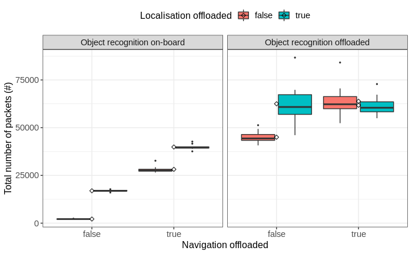

```r
#pdf(file = "../../figures/known_map_experiment/number-of-packets-1.pdf")

facet_values <- c('false'='Object recognition on-board',
            'true'='Object recognition offloaded')

ggplot(data, aes(x = navigation_offloaded, y = num_of_packets, fill = amcl_offloaded)) +
  theme_bw() +
  geom_boxplot(width = 0.9, outlier.size = 0.5) +
  stat_summary(fun = mean, color = 'black', geom = 'point', shape = 5) +
  labs(x = "Navigation offloaded", y = "Total number of packets (#)") +
  guides(fill=guide_legend(title="Localisation offloaded")) +
  facet_wrap(facets = ~obj_recognition_offloaded, labeller = labeller(.multi_line = TRUE, obj_recognition_offloaded = facet_values)) +
  theme(
    axis.title.x = element_text(size = 12, family = 'sans'),
    axis.title.y = element_text(size = 12, family = 'sans'),
    axis.text.x = element_text(size = 11, family = 'sans'),
    axis.text.y = element_text(size = 11, family = 'sans'),
    legend.title = element_text(size = 12, family = 'sans'),
    legend.text = element_text(size = 11, family = 'sans'),
    legend.position = "top",
    strip.text = element_text(size = 11, family = 'sans')
  )
```

```r
#dev.off()
```